# Analysis of an MLDS experiment

Guillermo Aguilar

2025-08-24

This notebook shows how to analyze data obtained in an MLDS experiment using the R package `MLDS`. The notebook is divided into four parts:

1. Loading and parsing data
2. Estimating the perceptual scale
3. Calculating confidence intervals
4. Evaluating goodness of fit.

To start, we need to have the `MLDS` packaged installed and loading in our R session.

```r
# uncomment to install package if you don't have it.
# you only need to do this once.

#install.packages('MLDS')

# loading package into the session
library(MLDS)
```

### 1. Loading and parsing data

#### Loading data

The first step in the analysis is to load the data from the experiment, and parse them to the format the functions in the `MLDS` package understands.

The following code loads a CSV file containing data from an MLDS experiment on perceived numerosity. This was an experiment programmed with Psychopy and run online with Pavlovia.

```r
# Loading a file from an observer
# Here we have three different observers, uncomment or edit as needed.
fname <- 'data/mlds/GA.csv'
#fname <- 'data/mlds/JXV.csv'
#fname <- 'data/mlds/CH.csv'
#fname <- 'data/mlds/XX.csv' ## your file here

df <- read.csv(fname)
df
```

| instruct.started | instruct.stopped | session | participant | date | expName | psychopyVersion | OS | frameRate | trial.started | trial.stopped | resp.keys | resp.rt | resp.duration | trials.thisRepN | trials.thisTrialN | trials.thisN | trials.thisIndex | trials.ran | trial | s1 | s2 | s3 | im1 | im2 | im3 | thanks.started | thanks.stopped |
| --- | --- | --- | --- | --- | --- | --- | --- | --- | --- | --- | --- | --- | --- | --- | --- | --- | --- | --- | --- | --- | --- | --- | --- | --- | --- | --- | --- |
| 3e-04 | 1.3147 | 1 | GA | 2025-08-18_16h49.21.233 | mlds_experiment_numerosity_triads | 2025.1.1 | Linux x86_64 | 59.88024 | NA | NA |  | NA | NA | NA | NA | NA | NA | NA | NA | NA | NA | NA |  |  |  | NA | NA |
| NA | NA | 1 | GA | 2025-08-18_16h49.21.233 | mlds_experiment_numerosity_triads | 2025.1.1 | Linux x86_64 | 59.88024 | 1.3380 | 4.8157 | right | 2.9365 | NA | 0 | 0 | 0 | 0 | 1 | 0 | 60 | 20 | 5 | s_60_r_2.png | s_20_r_7.png | s_5_r_6.png | NA | NA |
| NA | NA | 1 | GA | 2025-08-18_16h49.21.233 | mlds_experiment_numerosity_triads | 2025.1.1 | Linux x86_64 | 59.88024 | 4.8174 | 7.2509 | left | 1.8894 | NA | 0 | 1 | 1 | 1 | 1 | 1 | 50 | 33 | 10 | s_50_r_2.png | s_33_r_8.png | s_10_r_3.png | NA | NA |
| NA | NA | 1 | GA | 2025-08-18_16h49.21.233 | mlds_experiment_numerosity_triads | 2025.1.1 | Linux x86_64 | 59.88024 | 7.2523 | 8.5352 | right | 0.7378 | NA | 0 | 2 | 2 | 2 | 1 | 2 | 60 | 10 | 5 | s_60_r_5.png | s_10_r_8.png | s_5_r_2.png | NA | NA |
| NA | NA | 1 | GA | 2025-08-18_16h49.21.233 | mlds_experiment_numerosity_triads | 2025.1.1 | Linux x86_64 | 59.88024 | 8.5371 | 10.5039 | right | 1.4238 | NA | 0 | 3 | 3 | 3 | 1 | 3 | 10 | 33 | 60 | s_10_r_3.png | s_33_r_8.png | s_60_r_9.png | NA | NA |
| NA | NA | 1 | GA | 2025-08-18_16h49.21.233 | mlds_experiment_numerosity_triads | 2025.1.1 | Linux x86_64 | 59.88024 | 10.5055 | 11.7378 | right | 0.6933 | NA | 0 | 4 | 4 | 4 | 1 | 4 | 5 | 33 | 60 | s_5_r_2.png | s_33_r_4.png | s_60_r_10.png | NA | NA |
| NA | NA | 1 | GA | 2025-08-18_16h49.21.233 | mlds_experiment_numerosity_triads | 2025.1.1 | Linux x86_64 | 59.88024 | 11.7395 | 14.8738 | left | 2.5996 | NA | 0 | 5 | 5 | 5 | 1 | 5 | 10 | 15 | 33 | s_10_r_10.png | s_15_r_7.png | s_33_r_8.png | NA | NA |
| NA | NA | 1 | GA | 2025-08-18_16h49.21.233 | mlds_experiment_numerosity_triads | 2025.1.1 | Linux x86_64 | 59.88024 | 14.8748 | 16.5755 | right | 1.1728 | NA | 0 | 6 | 6 | 6 | 1 | 6 | 20 | 15 | 5 | s_20_r_7.png | s_15_r_8.png | s_5_r_7.png | NA | NA |
| NA | NA | 1 | GA | 2025-08-18_16h49.21.233 | mlds_experiment_numerosity_triads | 2025.1.1 | Linux x86_64 | 59.88024 | 16.5775 | 17.8765 | right | 0.7562 | NA | 0 | 7 | 7 | 7 | 1 | 7 | 5 | 33 | 50 | s_5_r_4.png | s_33_r_2.png | s_50_r_1.png | NA | NA |
| NA | NA | 1 | GA | 2025-08-18_16h49.21.233 | mlds_experiment_numerosity_triads | 2025.1.1 | Linux x86_64 | 59.88024 | 17.8775 | 22.4474 | left | 4.0327 | NA | 0 | 8 | 8 | 8 | 1 | 8 | 33 | 25 | 5 | s_33_r_1.png | s_25_r_9.png | s_5_r_9.png | NA | NA |

[output cut: 248 more lines]

As you can see the CSV file contains many columns that Psychopy automatically saves. Not all columns are relevant, we will filter them later.

We can also load the single runs and concatenate them here in R

```r
# Loading multiple files, uncomment to try it out. Edit with your files as needed.
#fname1 <- 'data/mlds/GA1.csv'
#fname2 <- 'data/mlds/GA2.csv'
#fname3 <- 'data/mlds/GA3.csv'
#df1 <- read.csv(fname1)
#df2 <- read.csv(fname2)
#df3 <- read.csv(fname3)
#df <- rbind(df1, df2, df3)
#df
```

Now we only keep the columns relevant for our analysis. These are:

- s1, s2, s3: the stimulus values presented in each trial
- resp.keys: what button the observer pressed.

```r
df <- df[c('resp.keys', 's1', 's2', 's3')]
df
```

| resp.keys | s1 | s2 | s3 |
| --- | --- | --- | --- |
|  | NA | NA | NA |
| right | 60 | 20 | 5 |
| left | 50 | 33 | 10 |
| right | 60 | 10 | 5 |
| right | 10 | 33 | 60 |
| right | 5 | 33 | 60 |
| left | 10 | 15 | 33 |
| right | 20 | 15 | 5 |
| right | 5 | 33 | 50 |
| left | 33 | 25 | 5 |

[output cut: 248 more lines]

#### Parsing data to format needed by MLDS

We need to map the key presses to 0’s or 1’s. We do this with the following call and save the responses in a new column called `resp`.

```r
df$resp <- as.numeric(df$resp.keys == 'left')
df
```

| resp.keys | s1 | s2 | s3 | resp |
| --- | --- | --- | --- | --- |
|  | NA | NA | NA | 0 |
| right | 60 | 20 | 5 | 0 |
| left | 50 | 33 | 10 | 1 |
| right | 60 | 10 | 5 | 0 |
| right | 10 | 33 | 60 | 0 |
| right | 5 | 33 | 60 | 0 |
| left | 10 | 15 | 33 | 1 |
| right | 20 | 15 | 5 | 0 |
| right | 5 | 33 | 50 | 0 |
| left | 33 | 25 | 5 | 1 |

[output cut: 248 more lines]

Now we remove NaNs entered automatically by Psychopy

```r
df <- na.omit(df)
df
```

|  | resp.keys | s1 | s2 | s3 | resp |
| --- | --- | --- | --- | --- | --- |
| 2 | right | 60 | 20 | 5 | 0 |
| 3 | left | 50 | 33 | 10 | 1 |
| 4 | right | 60 | 10 | 5 | 0 |
| 5 | right | 10 | 33 | 60 | 0 |
| 6 | right | 5 | 33 | 60 | 0 |
| 7 | left | 10 | 15 | 33 | 1 |
| 8 | right | 20 | 15 | 5 | 0 |
| 9 | right | 5 | 33 | 50 | 0 |
| 10 | left | 33 | 25 | 5 | 1 |
| 11 | right | 15 | 20 | 40 | 0 |

[output cut: 242 more lines]

The input to MLDS is a data frame that contains the *indices* of the presented stimuli, not the stimulus values themselves. In the following code we do this by explicitly set a stimulus vector, and we replace the values with its corresponding index on that vector.

```r
# vector of stimulus values
stim_vector <- c(5, 10, 15, 20, 25, 33, 40, 50, 60)
stim_index <- seq(length(stim_vector))

for (i in 1:length(stim_vector)) {
  df$s1 <- replace(df$s1, df$s1==stim_vector[i], stim_index[i])
  df$s2 <- replace(df$s2, df$s2==stim_vector[i], stim_index[i])
  df$s3 <- replace(df$s3, df$s3==stim_vector[i], stim_index[i])
}

data <- df[c('resp', 's1', 's2', 's3')]

# we rename the columns
colnames(data) <- c("Resp", "S1", "S2", "S3")

data
```

|  | Resp | S1 | S2 | S3 |
| --- | --- | --- | --- | --- |
| 2 | 0 | 9 | 4 | 1 |
| 3 | 1 | 8 | 6 | 2 |
| 4 | 0 | 9 | 2 | 1 |
| 5 | 0 | 2 | 6 | 9 |
| 6 | 0 | 1 | 6 | 9 |
| 7 | 1 | 2 | 3 | 6 |
| 8 | 0 | 4 | 3 | 1 |
| 9 | 0 | 1 | 6 | 8 |
| 10 | 1 | 6 | 5 | 1 |
| 11 | 0 | 3 | 4 | 7 |

[output cut: 242 more lines]

This last data frame, `data`, is in the correct format ready for MLDS.

### 2. Estimating the perceptual scale

We now estimate the scale by calling the functions from the `MLDS` package. We give the data to the function `as.mlbs.df` to transform the data frame into one that `MLDS` takes as input. We also pass the stimulus vector so that the functions later will know to which values each index corresponds.

```r
data <- as.mlbs.df(data, stim_vector)
```

And now we call the main estimation function, `mlds()`, save the result in a variable and we print the output.

```r
scale <- mlds(data)
scale
```

```
##
## Perceptual Scale:
##     5    10    15    20    25    33    40    50    60
## 0.000 0.409 0.739 1.442 1.796 2.201 2.679 2.876 2.872
##
## sigma:
## [1] 1
```

The variable `scale` contains the estimated scale, but also all the data and specifics of the estimation procedure using the GLM. The stimulus and scale vectors can be accessed with

```r
print(scale$stimulus)
```

```
## [1]  5 10 15 20 25 33 40 50 60
```

and

```r
print(scale$pscale)
```

```
##                  S2        S3        S4        S5        S6        S7        S8
## 0.0000000 0.4092077 0.7387621 1.4415521 1.7962994 2.2014261 2.6790081 2.8761768
##        S9
## 2.8723338
```

The package also comes with a plotting routine for the scale output, as shown in the following code.

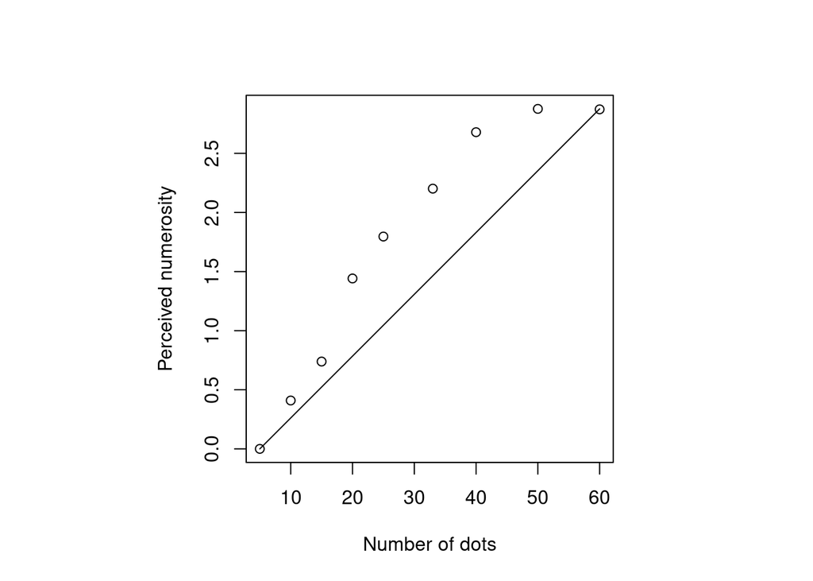

```r
par(pty="s")
plot(scale, xlab = "Number of dots", ylab = "Perceived numerosity")
lines(c(min(scale$stimulus), max(scale$stimulus)), c(0, max(scale$pscale)), type = "l", lty = 1)
```

*Disclaimer: The notebook uses only functions from R-base and does not use functions from other packages. This is on purpose, to keep the code flexible and compatible with most users. Better plots can be created witht `ggplot`, but this is left here to the user*

### 3. Calculating confidence intervals

In MLDS confidence intervals are calculated via bootstrap. The logic is the following. First, the estimated parameters for the scale are used (via the GLM) to get the choice probability for each triad. Then these probabilities are used to generate simulated data, which is then fed into the estimation routine to get a bootstrapped sample of the parameters. The process is repeated many times (here 1000 times), to get a distribution of boostrapped parameters. From the distribution confidence intervals can be calculated.

The bootstrap simulation is already implemented in the package in function `boot.mlds`

```r
scale.boot <- boot.mlds(scale, nsim=1000)
```

The returned object `scale.boot` contains all the bootstrapped parameter samples. From them we (manually) calculate the bounds of the confidence intervals, as follows

```r
# calculating low and high bounds of confidence interval manually using quantiles,
# this procedure does not assume normal distribution of bootstrap samples
samples <- scale.boot$boot.samp
low <- c(0, apply(samples[1:(nrow(samples)-1),], 1, quantile, probs = 0.025))
high <- c(0, apply(samples[1:(nrow(samples)-1),], 1, quantile, probs = 0.975))
```

The variables `low` and `high`contains the CI bounds. We now can plot the scale with CIs

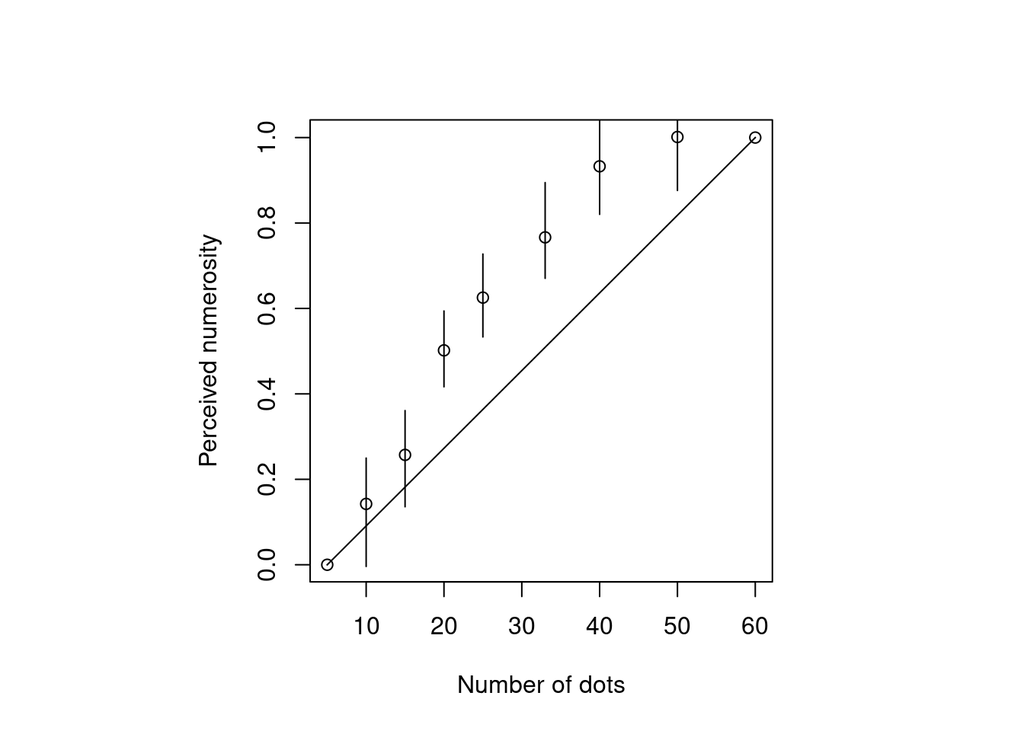

```r
par(pty="s")
plot(scale, xlab = "Number of dots", ylab = "Perceived numerosity", standard.scale = TRUE)
segments(scale$stimulus, low, scale$stimulus, high)
lines(c(min(scale$stimulus), max(scale$stimulus)), c(0, 1), type = "l", lty = 1)
```

### 4. Evaluating goodness of fit

Similar as for CIs, to evaluate goodness of fit MLDS also relies on simulation. Now instead of analysing the bootstrapped parameter samples, we evaluate the *deviance* on each simulation run. *Deviance* captures the deviation between model and data. It is the analogous to the sum of squared errors (SSE) in linear regression. The deviance is calculated for each datapoint as a *deviance residual*, similar to the residuals in linear regression.

The simulation and deviance calculation is done with function `binom.diagnostics`

```r
scale.gof <- binom.diagnostics(scale)
```

There are two checks on the deviance that the MLDS package considers. The first check is on the cumulative density function of the deviance residuals (left panel). Here the CDF is compared with the 95% envelope produced by the simulated data. An appropriate model should have all datapoints inside the envelope.

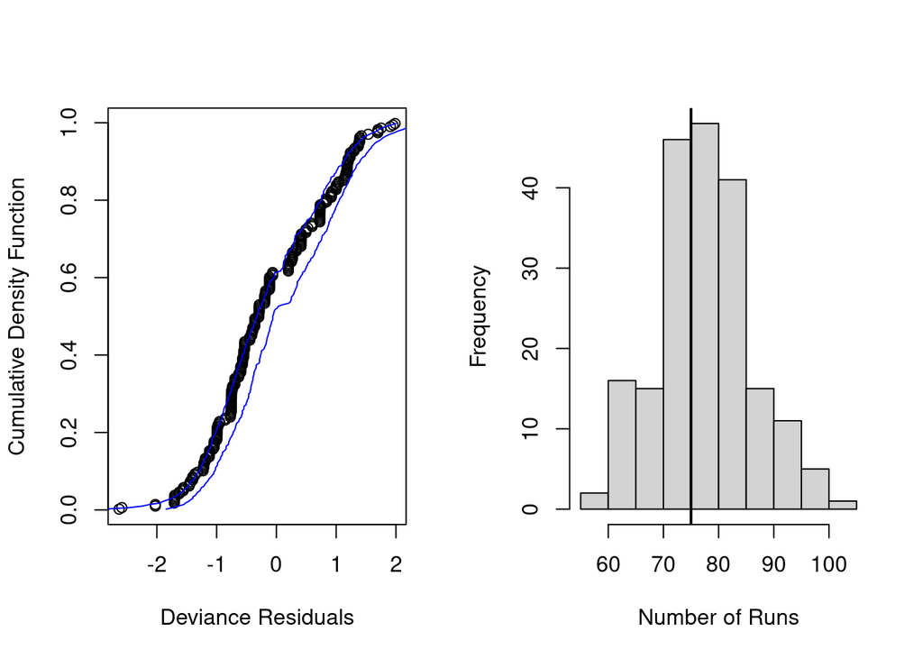

```r
plot(scale.gof)
```

The second check considers the order on the deviance residuals. In specific, it sorts the deviance residuals by the independent variable, and counts how many residuals have consecutively the same sign. This is the `number of runs` ( (vertical line on the histogram below, right panel). The same is done for each simulated run, to obtain a distribution of runs which is visualized as a histogram.

For an appropriate goodness of fit, the number of runs from the data (vertical line) should not be signifficantly different than the distribution. The `binom.diagnostics` function also calculates a p-value for this comparison, this should *not* be significant (p>0.05).

```r
print(scale.gof$p)
```

```
## [1] 0.395
```

Finding a “bad” goodness of fit indicates that the model assumptions behind MLDS are somehow violated. For example, it can indicate that the observer’s decision rule is not what MLDS assumes (a double differencing rule). Instead, the observer may be using another strategy to perform the task.

Another possibility is that the stimuli vary along more than one perceptual dimension. In this case judgments will be inconsistent with the decision model, if the observer considers a similarity distance in perceptual space, and that will produce a violation in the model assumptions. Experimenters may consider alternative models to investigate these cases further.